# Bayesian GLM Part1

Author

Murray Logan

Published

18/08/2026

# 1 Preparations

Load the necessary libraries

```r
library(tidyverse)       #for data wrangling etc
library(cmdstanr)        #for cmdstan
library(brms)            #for fitting models in STAN
library(standist)        #for exploring distributions
library(coda)            #for diagnostics
library(bayesplot)       #for diagnostics
library(DHARMa)          #for residual diagnostics
library(rstan)           #for interfacing with STAN
library(emmeans)         #for marginal means etc
library(broom)           #for tidying outputs
library(tidybayes)       #for more tidying outputs
library(HDInterval)      #for HPD intervals
library(broom.mixed)     #for summarising models
library(posterior)       #for posterior draws
library(patchwork)       #for multi-panel figures
library(bayestestR)      #for ROPE
library(easystats)       #framework for stats, modelling and visualisation
library(modelsummary)
library(tinytable)       #for tidy tables
library(marginaleffects)
theme_set(theme_grey())  #put the default ggplot theme back
source('helperFunctions.R')
bayesplot_theme_set(theme_bw(base_size = 8, base_family = "sans"))
```

# 2 Scenario

Here is an example from Fowler et al. (1998). An agriculturalist was interested in the effects of fertilizer load on the yield of grass. Grass seed was sown uniformly over an area and different quantities of commercial fertilizer were applied to each of ten 1 m<sup>2</sup> randomly located plots. Two months later the grass from each plot was harvested, dried and weighed. The data are in the file **fertilizer.csv** in the **data** folder.

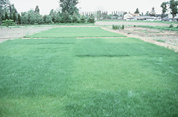

**Figure** 1: Field of grass

Format of the fertilizer.csv data file

| FERTILIZER | YIELD |
| --- | --- |
| 25 | 84 |
| 50 | 80 |
| 75 | 90 |
| 100 | 154 |
| 125 | 148 |
| … | … |

Description of the variables in the fertilizer data file

| **FERTILIZER**: | Mass of fertilizer (g.m<sup>-2</sup>) - Predictor variable |
| --- | --- |
| **YIELD**: | Yield of grass (g.m<sup>-2</sup>) - Response variable |

The aim of the analysis is to investigate the relationship between fertilizer concentration and grass yield.

# 3 Read in the data

We will start off by reading in the Fertilizer data. There are many functions in R that can read in a CSV file. We will use a the `read_csv()` function as it is part of the tidyverse ecosystem.

```r
fert <- read_csv("../data/fertilizer.csv", trim_ws = TRUE)
```

**glimpse**

```r
glimpse(fert)
```

```
Rows: 10
Columns: 2
$ FERTILIZER <dbl> 25, 50, 75, 100, 125, 150, 175, 200, 225, 250
$ YIELD      <dbl> 84, 80, 90, 154, 148, 169, 206, 244, 212, 248
```

**head**

```r
## Explore the first 6 rows of the data
head(fert)
```

```
# A tibble: 6 × 2
  FERTILIZER YIELD
       <dbl> <dbl>
1         25    84
2         50    80
3         75    90
4        100   154
5        125   148
6        150   169
```

**str**

```r
str(fert)
```

```
spc_tbl_ [10 × 2] (S3: spec_tbl_df/tbl_df/tbl/data.frame)
 $ FERTILIZER: num [1:10] 25 50 75 100 125 150 175 200 225 250
 $ YIELD     : num [1:10] 84 80 90 154 148 169 206 244 212 248
 - attr(*, "spec")=
  .. cols(
  ..   FERTILIZER = col_double(),
  ..   YIELD = col_double()
  .. )
 - attr(*, "problems")=<pointer: 0x0000015af52ea570>
```

**Easystats (datawizard)**

```r
fert |> datawizard::data_codebook()
```

```
fert (10 rows and 2 variables, 2 shown)

ID | Name       | Type    | Missings |    Values |  N
---+------------+---------+----------+-----------+---
1  | FERTILIZER | numeric | 0 (0.0%) | [25, 250] | 10
---+------------+---------+----------+-----------+---
2  | YIELD      | numeric | 0 (0.0%) | [80, 248] | 10
-----------------------------------------------------
```

**Skim (modelsummary)**

Unique

Missing Pct.

Mean

SD

Min

Median

Max

Histogram

FERTILIZER

10

0

137.5

75.7

25.0

137.5

250.0

[figure not shown]

YIELD

10

0

163.5

64.0

80.0

161.5

248.0

[figure not shown]

```r
fert |> modelsummary::datasummary_skim()
```

**tinytable**

https://vincentarelbundock.github.io/tinytable/

```r
fert |>
    tt()
```

**Table** 1: Yield of grass conditional on fertiliser concentration.

| FERTILIZER | YIELD |
| --- | --- |
| 25 | 84 |
| 50 | 80 |
| 75 | 90 |
| 100 | 154 |
| 125 | 148 |
| 150 | 169 |
| 175 | 206 |
| 200 | 244 |
| 225 | 212 |
| 250 | 248 |

OR with more flexible caption and label

**Table** 2: Yield of grass conditional on fertiliser concentration.

```r
fert |>
    tt()
```

| FERTILIZER | YIELD |
| --- | --- |
| 25 | 84 |
| 50 | 80 |
| 75 | 90 |
| 100 | 154 |
| 125 | 148 |
| 150 | 169 |
| 175 | 206 |
| 200 | 244 |
| 225 | 212 |
| 250 | 248 |

OR with sparklines

```r
plot_data <- list(fert$FERTILIZER, fert$YIELD)
dat <- data.frame(
  Variables = colnames(fert),
  Histogram = ""
)
dat |>
    tt() |>
    plot_tt(j = 2, fun = "histogram", data = plot_data)
```

**Table** 3: Yield of grass conditional on fertiliser concentration.

Variables

Histogram

FERTILIZER

[figure not shown]

YIELD

[figure not shown]

# 4 Exploratory data analysis

Model formula:

$$\begin{align}
y_i &\sim{} \mathcal{N}(\mu_i, \sigma^2)\\
\mu_i &= \beta_0 + \beta_1 x_i\\
\beta_0 &\sim{} \mathcal{N}(164, 90)\\
\beta_1 &\sim{} \mathcal{N}(0, 90)\\
\sigma &\sim{} \mathcal{t}(3,0,90)\\
\end{align}$$
$$\begin{align}y_i &\sim{} \mathcal{N}(\mu_i, \sigma^2)\\\mu_i &= \beta_0 + \beta_1 x_i\\\beta_0 &\sim{} \mathcal{N}(164, 90)\\\beta_1 &\sim{} \mathcal{N}(0, 90)\\\sigma &\sim{} \mathcal{t}(3,0,90)\\\end{align}$$

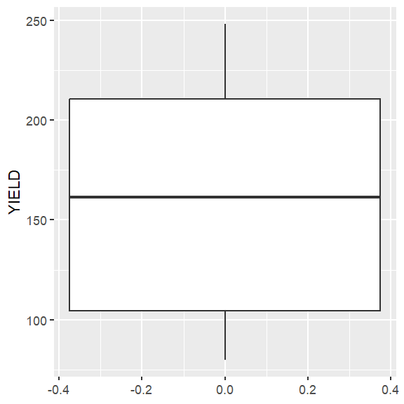

```r
fert |> ggplot(aes(y = YIELD)) +
  geom_boxplot()
```

```r
#looks symmetrical. Doesn't mean its normal but there's nothing obviously wrong
```

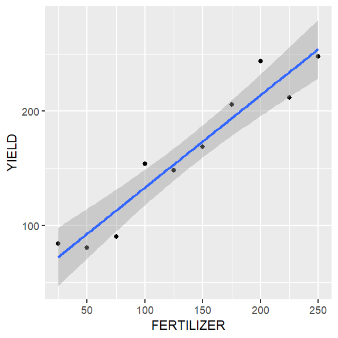

```r
fert |> ggplot(aes(y = YIELD, x = FERTILIZER)) +
  geom_point() +
  geom_smooth(method = "lm")
```

```r
#looks linear!!
#variance looks the same across all points
```

# 5 Fit the model

Note, for routines that take more than a couple of seconds to perform (such as most Bayesian models), it is a good idea to cache the quarto or Rmarkdown chunks in which the routine is performed. That way, the routine will only be run the first time and any objects generated will be stored for future use. Thereafter, provided the code has not changed, the routine will not be re-run. Rather, `knitr` will just retrieve the cached objects and continue on.

One of the most difficult aspects of performing Bayesian analyses is the specification of priors. For instances where there are some previous knowledge available and a desire to incorporate those data, the difficulty is in how to ensure that the information is incorporated correctly. However, for instances where there are no previous relevant information and so a desire to have the posteriors driven entirely by the new data, the difficulty is in how to define priors that are both vague enough (not bias results in their direction) and yet not so vague as to allow the MCMC sampler to drift off into unsupported regions (and thus get stuck and yield spurious estimates).

The degree to which priors **influence** an outcome (whether by having a pulling effect on the estimates or by encouraging the sampler to drift off into unsupported regions of the posterior) is dependent on:

- the relative sparsity of the data - the larger the data, the less weight the priors have and thus less influence they exert.
- the complexity of the model (and thus posterior) - the more parameters, the more sensitive the sampler is to the priors.

The sampled posterior is the product of both the likelihood and the prior - all of which are multidimensional. For most applications, it would be vertically impossible to define a sensible multidimensional prior. Hence, our only option is to define priors on individual parameters (e.g. the intercept, slope(s), variance etc) and to hope that if they are individually sensible, they will remain collectively sensible.

So having (hopefully) impressed upon the notion that priors are an important consideration, I will now attempt to synthesise some of the approaches that can be employed to arrive at weakly informative priors that have been gleaned from various sources. Largely, this advice has come from the following resources:

- https://github.com/stan-dev/stan/wiki/Prior-Choice-Recommendations
- http://svmiller.com/blog/2021/02/thinking-about-your-priors-bayesian-analysis/

I will outline some of the current main recommendations before summarising some approaches in a table.

- weakly informative priors should contain enough information so as to regularise (discourage unreasonable parameter estimates whilst allowing all reasonable estimates).
- for effects parameters on scaled data, an argument could be made for a normal distribution with a standard deviation of 1 (e.g. `normal(0,1)`), although some prefer a t distribution with 3 degrees of freedom and standard deviation of 1 (e.g. `student_t(3,0,1)`) - apparently a flatter t is a more robust prior than a normal as an uninformative prior…
- for unscaled data, the above priors can be scaled by using the standard deviation of the data as the prior standard deviation (e.g. `student_t(3,0,sd(y))`, or `student_t(3,0,sd(y)/sd(x))`)
- for priors of hierachical standard deviations, priors should encourage shrinkage towards 0 (particularly if the number of groups is small, since otherwise, the sampler will tend to be more responsive to “noise”).

| Family | Parameter | brms | rstanarm |
| --- | --- | --- | --- |
| Gaussian | Intercept | `student_t(3,median(y),mad(y))` | `normal(mean(y),2.5*sd(y))` |
|  | ‘Population effects’ (slopes, betas) | flat, improper priors | `normal(0,2.5*sd(y)/sd(x))` |
|  | Sigma | `student_t(3,0,mad(y))` | `exponential(1/sd(y))` |
|  | ‘Group-level effects’ | `student_t(3,0,mad(y))` | `decov(1,1,1,1)` |
|  | Correlation on group-level effects | `ljk_corr_cholesky(1)` |  |
| Poisson | Intercept | `student_t(3,median(y),mad(y))` | `normal(mean(y),2.5*sd(y))` |
|  | ‘Population effects’ (slopes, betas) | flat, improper priors | `normal(0,2.5*sd(y)/sd(x))` |
|  | ‘Group-level effects’ | `student_t(3,0,mad(y))` | `decov(1,1,1,1)` |
|  | Correlation on group-level effects | `ljk_corr_cholesky(1)` |  |
| Negative binomial | Intercept | `student_t(3,median(y),mad(y))` | `normal(mean(y),2.5*sd(y))` |
|  | ‘Population effects’ (slopes, betas) | flat, improper priors | `normal(0,2.5*sd(y)/sd(x))` |
|  | Shape | `gamma(0.01, 0.01)` | `exponential(1/sd(y))` |
|  | ‘Group-level effects’ | `student_t(3,0,mad(y))` | `decov(1,1,1,1)` |
|  | Correlation on group-level effects | `ljk_corr_cholesky(1)` |  |

Notes:

`brms`

https://github.com/paul-buerkner/brms/blob/c2b24475d727c8afd8bfc95947c18793b8ce2892/R/priors.R

1. In the above, for non-Gaussian families, `y` is first transformed according to the family link. If the family link is `log`, then 0.1 is first added to 0 values.
2. in `brms` the minimum standard deviation for the Intercept prior is `2.5`
3. in `brms` the minimum standard deviation for group-level priors is `10`.

`rstanarm`

http://mc-stan.org/rstanarm/articles/priors.html

1. in `rstanarm` priors on standard deviation and correlation associated with group-level effects are packaged up into a single prior (`decov` which is a decomposition of the variance and covariance matrix).

```r
#median is more robust and not influenced heavily by outliers (except for zero-inflated data)
fert$YIELD |> median()
```

```
[1] 161.5
```

```r
#mad is more robust than SD (median absolute deviation)
fert$YIELD |> mad()
```

```
[1] 90.4386
```

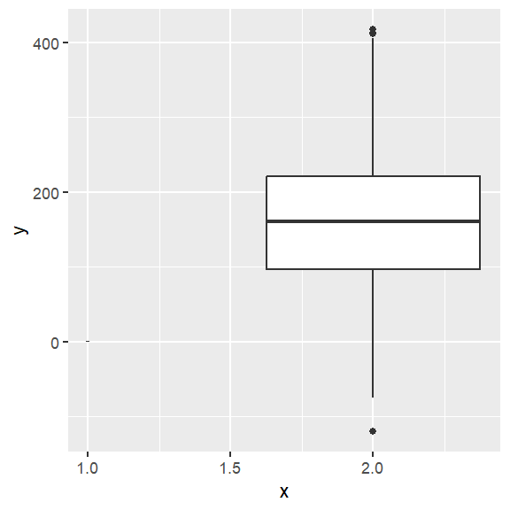

```r
#diagnostics
x <- rnorm(n = 1000, mean = 161.5, sd = 90)

ggplot(fert, aes(y + YIELD))+
  geom_boxplot(aes(x = 1))+
  geom_boxplot(data = data.frame(x = 2, y = x),
               aes(x = x, y = y))
```

```r
#is usually just the difference between the smallest and largest y values divided by 1
#but usually just use 0 as the prior mean, and the same variance as the intercept that we already calculated (90 in this case)
```

```r
#this needs to be constrained, variance cannot go below 0 --> so we use a half t-distribution. Think of it
#as a very flat normal distribution

#df = 3
#sd = 90
```

#defining formula

```r
#YIELD = response
#FERTILIZER = predictor (scaled)
#bf = bayesian formula --> can do fancy things

#put scale() in the formula instead of making a new variable so the model can automatically back transform
#you dont have to manually do this

fert_form <- bf(YIELD ~ scale(FERTILIZER))

#ask brms package for its recommended priors just to check
get_prior(fert_form, data = fert)
```

```
                     prior     class            coef group resp dpar nlpar lb
                    (flat)         b
                    (flat)         b scaleFERTILIZER
 student_t(3, 161.5, 90.4) Intercept
     student_t(3, 0, 90.4)     sigma                                        0
 ub tag       source
             default
        (vectorized)
             default
             default
```